# Bayesian Small Area Estimation of Under-5 Malaria Prevalence in West Africa

A Space-Time BYM2 Fay-Herriot Model Across Ghana, Burkina Faso, and Côte d’Ivoire

2026-05-20

# 1 About the Data

## 1.1 Demographic and Health Surveys (DHS)

The data for this project is sourced from the Demographic and Health Surveys (DHS) program (Croft et al. 2018), which provides nationally representative datasets on health and population indicators. The specific datasets used in this analysis include two DHS rounds for each of the three selected countries: Ghana, Burkina Faso, and Côte d’Ivoire. For each survey round, two files are used: the **household member recode (PR) file**, containing individual-level data including the malaria biomarker, and the **GPS shapefile**, providing geospatial coordinates for the survey clusters.

```
Ghana:           DHS 2014 (GHPR72FL) and DHS 2022 (GHPR8CFL)
Burkina Faso:    DHS 2010 (BFPR62FL) and DHS 2021 (BFPR81FL)
Côte d'Ivoire:   DHS 2012 (CIPR62FL) and DHS 2021 (CIPR81FL)
```

## 1.2 Outcome Variable: Microscopy-Confirmed Malaria

We use microscopy-confirmed malaria infection (`hml32`) in children aged 6-59 months. While DHS also reports RDT results, microscopy is the recommended gold standard for prevalence estimation in survey-based studies (Florey 2014). Our direct estimates were validated against the published DHS report (26.7% in 2014 and 8.6% in 2022 for Ghana national prevalence), confirming correct variable identification and weighting procedure.

# 2 Data Loading and Cleaning

```r
survey_index <- tribble(
  ~country,        ~iso, ~year, ~round_id, ~pr_path, ~gps_path,
  "Ghana",         "GHA", 2014, 1L,
  "dhs_gh_14/GHPR72DT/GHPR72FL.DTA", "dhs_gh_14/GHGE71FL/GHGE71FL.shp",
  "Ghana",         "GHA", 2022, 2L,
  "dhs_gh_22/GHPR8CDT/GHPR8CFL.DTA", "dhs_gh_22/GHGE8AFL/GHGE8AFL.shp",
  "Burkina",       "BFA", 2010, 1L,
  "dhs_bf_10/BFPR62DT/BFPR62FL.DTA", "dhs_bf_10/BFGE61FL/BFGE61FL.shp",
  "Burkina",       "BFA", 2021, 2L,
  "dhs_bf_21/BFPR81DT/BFPR81FL.DTA", "dhs_bf_21/BFGE81FL/BFGE81FL.shp",
  "Cote d'Ivoire", "CIV", 2012, 1L,
  "dhs_ci_12/CIPR62DT/CIPR62FL.DTA", "dhs_ci_12/CIGE61FL/CIGE61FL.shp",
  "Cote d'Ivoire", "CIV", 2021, 2L,
  "dhs_ci_21/CIPR81DT/CIPR81FL.DTA", "dhs_ci_21/CIGE81FL/CIGE81FL.shp"
)
```

## 2.1 District Boundaries

District boundaries are obtained from the GADM database. We use Level 2 for Ghana (260 districts) and Level 3 for Burkina Faso (351 departments) and Côte d’Ivoire (113 departments). Boundaries are transformed to WGS 84 (EPSG:4326) to match the DHS GPS data.

```r
load_districts <- function(iso) {
  if (iso == "GHA") {
    gadm(country = iso, level = 2, path = "boundaries/") %>%
      st_as_sf() %>% st_transform(crs = 4326) %>%
      rename(district_name = NAME_2, district_code = GID_2) %>%
      mutate(iso = iso)
  } else {
    gadm(country = iso, level = 3, path = "boundaries/") %>%
      st_as_sf() %>% st_transform(crs = 4326) %>%
      rename(district_name = NAME_3, district_code = GID_3) %>%
      mutate(iso = iso)
  }
}

districts_raw <- list(
  GHA = load_districts("GHA"),
  BFA = load_districts("BFA"),
  CIV = load_districts("CIV")
)

# Create numeric district lookups (Stan requires integer indices)
district_lookups <- map(districts_raw, function(d) {
  d %>% st_drop_geometry() %>%
    select(district_name, district_code, iso) %>%
    mutate(district_id = row_number())
})

# Districts ordered by district_id for adjacency matrix construction
districts_ordered <- map2(districts_raw, district_lookups, function(d, lk) {
  d %>% left_join(lk, by = c("district_name", "district_code", "iso")) %>%
    arrange(district_id)
})

map_dfr(district_lookups, ~tibble(districts = nrow(.x)), .id = "iso")
```

```
## # A tibble: 3 × 2
##   iso   districts
##   <chr>     <int>
## 1 GHA         260
## 2 BFA         351
## 3 CIV         113
```

## 2.2 PR Files and Spatial Join

```r
load_pr <- function(pr_path, gps_path, iso, year, round_id,
                    districts_ordered, district_lookup) {
  gps <- read_sf(gps_path) %>%
    rename(cluster_id = DHSCLUST) %>%
    st_transform(crs = 4326)

  gps_joined <- st_join(gps, districts_ordered, join = st_nearest_feature) %>%
    select(cluster_id, district_name, district_code) %>%
    st_drop_geometry() %>%
    left_join(district_lookup, by = c("district_name", "district_code")) %>%
    select(cluster_id, district_id, district_name)

  pr <- read_dta(pr_path) %>%
    rename_with(tolower) %>%
    select(cluster_id = hv001, hh_id = hv002, line_id = hvidx,
           weight_raw = hv005, stratum = hv023,
           age_months = hc1, malaria = hml32) %>%
    filter(age_months < 60, malaria %in% c(0, 1)) %>%
    mutate(weight = weight_raw / 1e6,
           malaria = as.integer(malaria),
           cluster_id = as.integer(cluster_id),
           stratum = as.integer(stratum),
           country = iso, year = year, round_id = round_id) %>%
    left_join(gps_joined, by = "cluster_id")

  pr
}

pr_list <- pmap(survey_index, function(country, iso, year, round_id, pr_path, gps_path) {
  load_pr(pr_path, gps_path, iso, year, round_id,
          districts_ordered[[iso]], district_lookups[[iso]])
})
```

# 3 Direct Estimation

For each observed district-year, we compute weighted prevalence using the Hájek ratio estimator (Hájek 1971):

$$\hat{p}_{it}^w = \frac{\sum_k d_k
y_k}{\sum_k d_k}$$

where $d_k$ is the DHS sampling weight and $y_k$ is the binary malaria indicator. Design-based standard errors are obtained via Taylor-series linearisation (Binder 1983) accounting for the two-stage stratified cluster design, implemented via the R `survey` package (Lumley 2010).

To use these estimates in a Fay-Herriot framework (Wakefield et al. 2020) with a Gaussian likelihood, we transform to the logit scale and apply the delta method for the standard error:

$$y_{it} = \text{logit}(\hat{p}_{it}^w),
\quad \widehat{\text{SE}}(y_{it}) =
\frac{\widehat{\text{SE}}(\hat{p}_{it}^w)}{\hat{p}_{it}^w(1 -
\hat{p}_{it}^w)}$$

For numerical stability, prevalences are bounded at $[0.02, 0.98]$ before logit transformation, and logit-scale standard errors $\psi_{it}$ are bounded at $[0.1, 2.0]$ to prevent degenerate likelihood contributions in extreme cases (Wakefield et al. 2020).

```r
get_direct_estimates <- function(pr) {
  design <- svydesign(
    ids = ~cluster_id, strata = ~stratum, weights = ~weight,
    data = pr, nest = TRUE
  )
  svyby(formula = ~malaria, by = ~district_id, design = design,
        FUN = svymean, na.rm = TRUE, keep.var = TRUE) %>%
    rename(p_hat = malaria, se_p = se) %>%
    filter(!is.na(p_hat), !is.na(se_p),
           se_p > 0, p_hat > 0, p_hat < 1) %>%
    mutate(
      country   = pr$country[1],
      iso       = pr$country[1],
      year      = pr$year[1],
      round_id  = pr$round_id[1],
      p_bounded = pmax(0.02, pmin(0.98, p_hat)),
      y_i       = log(p_bounded / (1 - p_bounded)),
      logit_var = se_p^2 / (pmax(0.02, p_hat)^2 * pmax(0.02, 1 - p_hat)^2),
      psi_i     = pmax(0.1, pmin(sqrt(logit_var), 2.0))
    ) %>%
    filter(is.finite(y_i), is.finite(psi_i)) %>%
    select(country, iso, year, round_id, district_id, y_i, psi_i)
}

direct_est_list <- map(pr_list, get_direct_estimates)
direct_est_all  <- bind_rows(direct_est_list)

direct_est_all %>% count(country, year, name = "observed_districts")
```

```
##   country year observed_districts
## 1     BFA 2010                232
## 2     BFA 2021                153
## 3     CIV 2012                 80
## 4     CIV 2021                103
## 5     GHA 2014                153
## 6     GHA 2022                124
```

# 4 Panel Construction

A balanced panel is constructed by taking the Cartesian product of districts and survey rounds for each country. Observed district-years receive their direct estimates; unobserved cells remain `NA` with an explicit `observed = 0` flag. This structure enables the Bayesian model to predict prevalence for unobserved districts through spatial borrowing, while applying the likelihood only to observed cells.

```r
build_panel <- function(country_iso, district_lookup, direct_est_all) {
  rounds <- direct_est_all %>%
    filter(country == country_iso) %>%
    distinct(year) %>% arrange(year) %>%
    mutate(round_id = row_number())

  est_clean <- direct_est_all %>%
    filter(country == country_iso) %>%
    select(district_id, year, y_i, psi_i)

  expand_grid(
    district_id = district_lookup$district_id,
    year        = rounds$year
  ) %>%
    left_join(district_lookup %>% select(district_id, district_name, district_code),
              by = "district_id") %>%
    left_join(est_clean, by = c("district_id", "year")) %>%
    left_join(rounds, by = "year") %>%
    arrange(year, district_id) %>%
    mutate(country = country_iso,
           observed = as.integer(!is.na(y_i)))
}

panels <- map(c("GHA", "BFA", "CIV"),
              ~build_panel(.x, district_lookups[[.x]], direct_est_all))
names(panels) <- c("GHA", "BFA", "CIV")

map_dfr(panels, function(p) {
  p %>% group_by(year) %>%
    summarise(total = n(), observed = sum(observed == 1),
              pct = round(100 * observed / total, 1), .groups = "drop")
}, .id = "country")
```

```
## # A tibble: 6 × 5
##   country  year total observed   pct
##   <chr>   <dbl> <int>    <int> <dbl>
## 1 GHA      2014   260      153  58.8
## 2 GHA      2022   260      124  47.7
## 3 BFA      2010   351      232  66.1
## 4 BFA      2021   351      153  43.6
## 5 CIV      2012   113       80  70.8
## 6 CIV      2021   113      103  91.2
```

# 5 Spatial Adjacency and BYM2 Scaling Factor

District adjacency is defined using queen contiguity (Bivand et al. 2013). Islands are reconnected using a snap tolerance of 0.1 degrees to ensure a fully connected graph, a necessary condition for a proper ICAR prior (Freni-Sterrantino et al. 2018).

From the binary adjacency matrix $\mathbf{W}$, we construct the ICAR precision matrix $\mathbf{Q}_{\text{ICAR}} = \mathbf{D} - \mathbf{W}$, where $\mathbf{D}$ is the diagonal matrix of neighbour counts (Besag et al. 1991). Because $\mathbf{Q}_{\text{ICAR}}$ is rank-deficient by one, its marginal variances depend on graph structure. Following Riebler et al. (2016), we compute the BYM2 scaling factor $s$ as the geometric mean of the marginal variances:

$$s =
\exp\!\left(\frac{1}{N}\sum_{i=1}^{N} \log
[\mathbf{Q}_{\text{ICAR}}^{-}]_{ii}\right)$$

Dividing the ICAR component by $\sqrt{s}$ in the BYM2 formula ensures its geometric-mean marginal variance equals one, making $\phi$ interpretable as the proportion of district-level variance that is spatially structured.

```r
compute_scaling_factor <- function(nb, D) {
  adj_mat <- nb2mat(nb, style = "B", zero.policy = TRUE)
  Q_icar  <- Diagonal(x = rowSums(adj_mat)) - as(adj_mat, "sparseMatrix")
  eps <- 0.001
  Q_reg <- Q_icar + eps * Diagonal(D)
  Q_inv_diag <- diag(solve(Q_reg))
  exp(mean(log(Q_inv_diag)))
}

build_spatial <- function(iso, districts_ordered) {
  D <- nrow(districts_ordered)
  nb <- poly2nb(districts_ordered, queen = TRUE)
  if (sum(sapply(nb, length) == 0) > 0) {
    nb <- poly2nb(districts_ordered, queen = TRUE, snap = 0.1)
  }

  adj_mat <- nb2mat(nb, style = "B", zero.policy = TRUE)
  edges <- which(adj_mat == 1, arr.ind = TRUE) %>%
    as.data.frame() %>%
    filter(row < col)

  scaling_factor <- compute_scaling_factor(nb, D)

  list(D = D, nb = nb,
       node1 = edges$row, node2 = edges$col,
       N_edges = nrow(edges),
       scaling_factor = scaling_factor)
}

spatial <- map(c("GHA", "BFA", "CIV"),
               ~build_spatial(.x, districts_ordered[[.x]]))
names(spatial) <- c("GHA", "BFA", "CIV")

map_dfr(spatial, function(s) {
  tibble(N = s$D, N_edges = s$N_edges, scaling_factor = round(s$scaling_factor, 3))
}, .id = "country")
```

```
## # A tibble: 3 × 4
##   country     N N_edges scaling_factor
##   <chr>   <int>   <int>          <dbl>
## 1 GHA       260     709           4.36
## 2 BFA       351     973           3.36
## 3 CIV       113     296           9.30
```

# 6 Covariates: Harmonised Multi-Country Panel

We use a harmonised covariate panel covering all three countries and both survey rounds, with seven standardised covariates derived from public geospatial sources. All covariates were standardised (mean 0, SD 1) to make coefficients directly comparable as per-standard-deviation effects, to allow a single weakly-informative prior $\beta_k \sim \mathcal{N}(0, 1)$ to apply to all coefficients, and to improve Hamiltonian Monte Carlo sampling efficiency (Stan Development Team 2024).

**Static covariates** (one value per district, applied to both rounds):

- `elev_std` Mean elevation (SRTM)
- `travel_std` Travel time to nearest healthcare facility (Weiss et al. 2020)
- `pop_dens_std` Log-transformed population density (WorldPop)
- `poverty_std` Multidimensional poverty headcount

**Time-varying covariates** (per district, per round):

- `rainfall_std` Mean annual precipitation (CHIRPS)
- `temp_std` Mean annual temperature
- `ntl_std` Nighttime lights composite (VIIRS) as a proxy for urbanicity and economic activity

We include both nighttime lights and population density. While these capture overlapping urbanicity signals, they index distinct dimensions of human settlement: population density reflects residential intensity, while nighttime lights also capture economic activity, infrastructure, and electrification (Elvidge et al. 2013; Bhatt et al. 2015). Both have featured in malaria SAE work, and we retain both subject to the multicollinearity check below.

```r
covariates_panel <- read_csv("three_country_model_panel.csv") %>%
  select(country, district_id, district_name, time, year, label,
         elev_std, rainfall_std, ntl_std, temp_std,
         travel_std, pop_dens_std, poverty_std)

covariates_panel %>% count(country, time, name = "rows")
```

```
## # A tibble: 6 × 3
##   country  time  rows
##   <chr>   <dbl> <int>
## 1 BFA         1   351
## 2 BFA         2   351
## 3 CIV         1   113
## 4 CIV         2   113
## 5 GHA         1   260
## 6 GHA         2   260
```

## 6.1 Joining Covariates to the Panel

The covariate panel’s `time` column (1, 2) maps directly to the survey panel’s `round_id` (1, 2), so the join is by `district_id` AND `time` — time-varying covariates correctly broadcast to the appropriate round, while static covariates carry the same value to both rounds.

```r
join_covariates <- function(iso) {
  panels[[iso]] %>%
    left_join(
      covariates_panel %>%
        filter(country == iso) %>%
        select(district_id, time,
               elev_std, rainfall_std, ntl_std, temp_std,
               travel_std, pop_dens_std, poverty_std),
      by = c("district_id", "round_id" = "time")
    )
}

panels <- list(
  GHA = join_covariates("GHA"),
  BFA = join_covariates("BFA"),
  CIV = join_covariates("CIV")
)

# Verify covariates are present
panels[["GHA"]] %>% select(district_id, year, ends_with("_std")) %>% head()
```

```
## # A tibble: 6 × 9
##   district_id  year elev_std rainfall_std ntl_std temp_std travel_std
##         <dbl> <dbl>    <dbl>        <dbl>   <dbl>    <dbl>      <dbl>
## 1           1  2014    0.639      -0.101   -0.600   -0.663     0.264
## 2           2  2014    0.411      -0.0293  -0.614   -0.694    -0.0426
## 3           3  2014    0.909      -0.119   -0.413   -1.30     -0.0370
## 4           4  2014    0.320      -0.0987  -0.578   -0.858    -0.381
## 5           5  2014    1.07       -0.0598  -0.582   -1.56     -0.654
## 6           6  2014    1.35       -0.0164  -0.569   -1.41     -0.480
## # ℹ 2 more variables: pop_dens_std <dbl>, poverty_std <dbl>
```

# 7 Exploratory Data Analysis

## 7.1 Correlation Heatmap

A visual check for multicollinearity among the seven covariates across all observations (three countries, two rounds each).

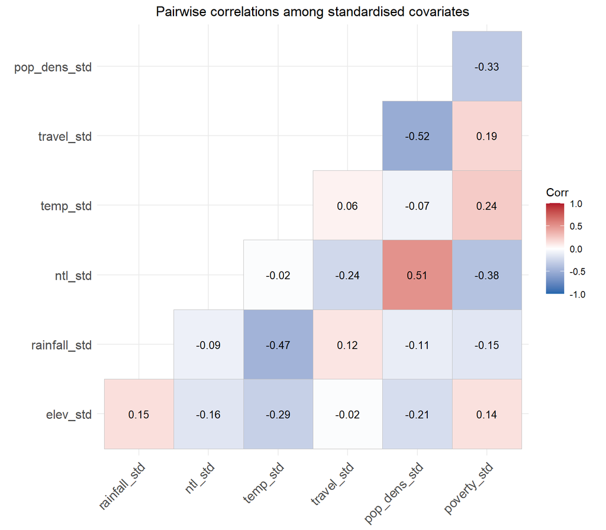

```r
covariate_cols <- c("elev_std", "rainfall_std", "ntl_std", "temp_std",
                    "travel_std", "pop_dens_std", "poverty_std")

cor_matrix <- covariates_panel %>%
  select(all_of(covariate_cols)) %>%
  cor(use = "complete.obs")

ggcorrplot(
  cor_matrix,
  type = "lower",
  lab = TRUE, lab_size = 3.5,
  colors = c("#2166ac", "white", "#b2182b"),
  title = "Pairwise correlations among standardised covariates",
  ggtheme = ggplot2::theme_minimal()
) +
  theme(plot.title = element_text(hjust = 0.5))
```

All retained pairwise correlations remain below approximately 0.7, consistent with the threshold recommended by Dormann et al. (2013) for multicollinearity concern in ecological regression. Notably, while `pop_dens_std` and `ntl_std` are moderately correlated (both index human concentration), they remain below the 0.7 threshold and are retained for the conceptual reasons noted above (Elvidge et al. 2013; Bhatt et al. 2015).

## 7.2 Distribution of Direct Estimates

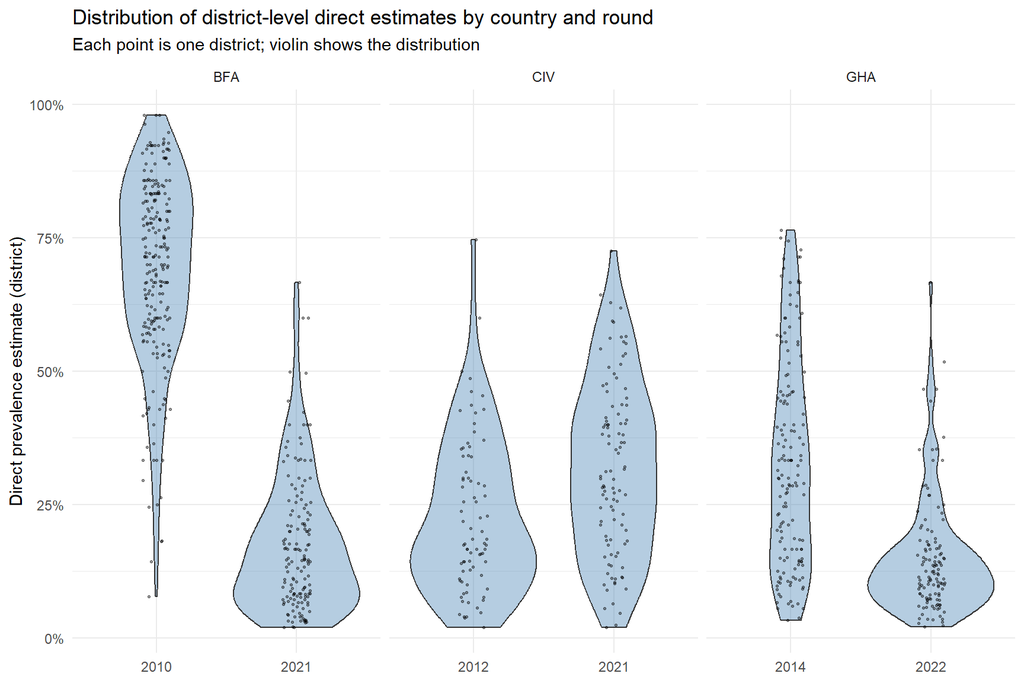

```r
direct_est_all %>%
  mutate(prevalence = plogis(y_i)) %>%
  ggplot(aes(x = factor(year), y = prevalence)) +
  geom_violin(fill = "steelblue", alpha = 0.4) +
  geom_jitter(width = 0.1, alpha = 0.4, size = 0.5) +
  facet_wrap(~country, scales = "free_x") +
  scale_y_continuous(labels = scales::percent_format(accuracy = 1)) +
  labs(x = NULL, y = "Direct prevalence estimate (district)",
       title = "Distribution of district-level direct estimates by country and round",
       subtitle = "Each point is one district; violin shows the distribution") +
  theme_minimal(base_size = 11)
```

## 7.3 Adjacency Graph (Ghana)

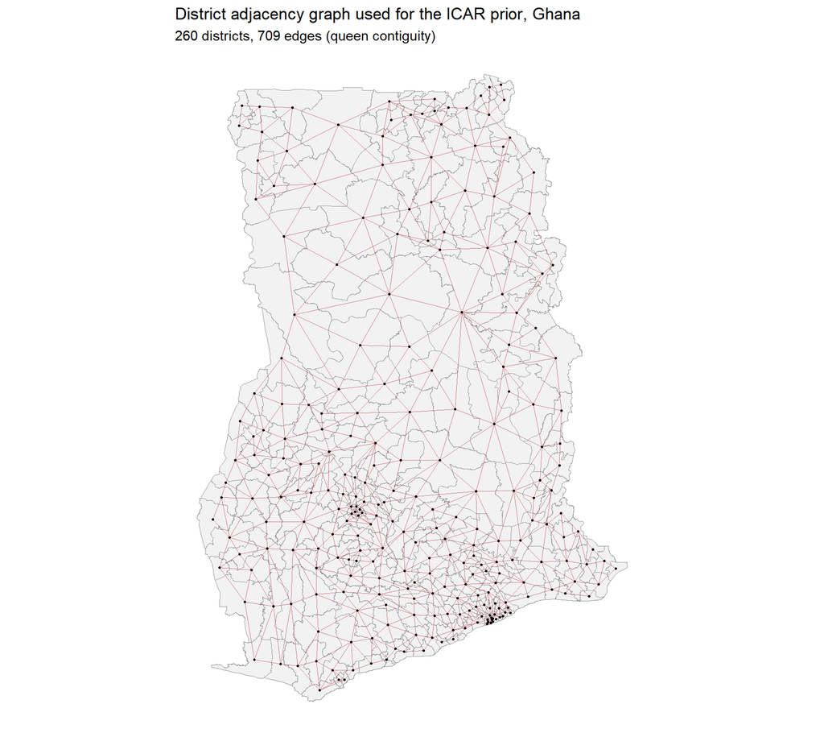

```r
gha_with_id <- districts_raw[["GHA"]] %>%
  left_join(district_lookups[["GHA"]] %>% select(district_id, district_code),
            by = "district_code") %>%
  arrange(district_id)

centroid_coords <- suppressWarnings(st_coordinates(st_centroid(gha_with_id)))
centroids <- tibble(
  district_id = gha_with_id$district_id,
  x = centroid_coords[, "X"], y = centroid_coords[, "Y"]
)

sp <- spatial[["GHA"]]
edges_df <- tibble(from_id = sp$node1, to_id = sp$node2) %>%
  left_join(centroids %>% rename(x_from = x, y_from = y),
            by = c("from_id" = "district_id")) %>%
  left_join(centroids %>% rename(x_to = x, y_to = y),
            by = c("to_id" = "district_id"))

ggplot() +
  geom_sf(data = districts_raw[["GHA"]],
          fill = "grey95", colour = "grey60", linewidth = 0.2) +
  geom_segment(data = edges_df,
               aes(x = x_from, y = y_from, xend = x_to, yend = y_to),
               colour = "#b2182b", alpha = 0.55, linewidth = 0.3) +
  geom_point(data = centroids, aes(x = x, y = y),
             colour = "black", size = 0.6) +
  labs(title = "District adjacency graph used for the ICAR prior, Ghana",
       subtitle = paste(sp$D, "districts,", sp$N_edges, "edges (queen contiguity)")) +
  theme_void(base_size = 11)
```

# 8 Stan Data Builders

Two builders mirror the two model specifications. The cross-sectional builder filters to a single year; the space-time builder uses both years.

```r
build_stan_data_cs <- function(iso, panels, spatial, year, covar_cols = NULL) {
  panel <- panels[[iso]] %>% filter(year == !!year)
  sp <- spatial[[iso]]
  obs_idx <- which(panel$observed == 1)

  if (!is.null(covar_cols)) {
    available <- intersect(covar_cols, names(panel))
    X <- if (length(available) > 0) as.matrix(panel[, available]) else matrix(0, nrow(panel), 0)
    K <- ncol(X)
  } else {
    X <- matrix(0, nrow(panel), 0)
    K <- 0L
  }

  list(N = sp$D, N_obs = length(obs_idx),
       obs_idx = obs_idx,
       y = panel$y_i[obs_idx], psi = panel$psi_i[obs_idx],
       N_edges = sp$N_edges, node1 = sp$node1, node2 = sp$node2,
       scaling_factor = sp$scaling_factor,
       K = K, X = X)
}
```

```r
build_stan_data_st <- function(iso, panels, spatial, covar_cols = NULL) {
  panel <- panels[[iso]]
  sp <- spatial[[iso]]
  obs_idx <- which(panel$observed == 1)

  if (!is.null(covar_cols)) {
    available <- intersect(covar_cols, names(panel))
    X <- if (length(available) > 0) as.matrix(panel[, available]) else matrix(0, nrow(panel), 0)
    K <- ncol(X)
  } else {
    X <- matrix(0, nrow(panel), 0)
    K <- 0L
  }

  list(N = sp$D, T = 2L, NT = nrow(panel),
       N_obs = length(obs_idx), obs_idx = obs_idx,
       district = panel$district_id, time = panel$round_id,
       y = panel$y_i[obs_idx], psi = panel$psi_i[obs_idx],
       N_edges = sp$N_edges, node1 = sp$node1, node2 = sp$node2,
       scaling_factor = sp$scaling_factor,
       K = K, X = X)
}
```

## 8.1 Assemble Stan Data for All Models

```r
covar_cols <- c("elev_std", "rainfall_std", "ntl_std", "temp_std",
                "travel_std", "pop_dens_std", "poverty_std")

stan_data <- list()

# Cross-sectional reference: Ghana 2022 only
stan_data[["GHA_CS_2022"]] <- build_stan_data_cs(
  "GHA", panels, spatial, year = 2022, covar_cols = covar_cols
)

# Space-time models for all three countries
stan_data[["GHA_ST"]] <- build_stan_data_st("GHA", panels, spatial, covar_cols = covar_cols)
stan_data[["BFA_ST"]] <- build_stan_data_st("BFA", panels, spatial, covar_cols = covar_cols)
stan_data[["CIV_ST"]] <- build_stan_data_st("CIV", panels, spatial, covar_cols = covar_cols)

map_dfr(stan_data, function(d) {
  tibble(
    N = d$N,
    NT = ifelse(is.null(d$NT), d$N, d$NT),
    N_obs = d$N_obs, K = d$K,
    N_edges = d$N_edges,
    scaling_factor = round(d$scaling_factor, 3)
  )
}, .id = "model")
```

```
## # A tibble: 4 × 7
##   model           N    NT N_obs     K N_edges scaling_factor
##   <chr>       <int> <int> <int> <int>   <int>          <dbl>
## 1 GHA_CS_2022   260   260   124     7     709           4.36
## 2 GHA_ST        260   520   277     7     709           4.36
## 3 BFA_ST        351   702   385     7     973           3.36
## 4 CIV_ST        113   226   183     7     296           9.30
```

# 9 Model Specification

## 9.1 Cross-Sectional Reference Model (Ghana 2022)

Following Wakefield et al. (2020), we begin with a cross-sectional Bayesian Fay-Herriot specification fitted to the most recent biomarker round in Ghana (2022). The latent logit prevalence for district $i$ decomposes as

$$\theta_i = \mu + b_i + \mathbf{x}_i^\top
\boldsymbol{\beta},$$

where $\mu$ is the national-level logit intercept, $b_i$ is the BYM2 district random effect, and $\mathbf{x}_i$ contains the seven standardised covariates. This specification serves two purposes: it provides a baseline estimate of district-level prevalence at the most policy-relevant time point, and it establishes a reference for the spatial hyperparameters $(\sigma_b, \phi)$ against which the space-time extension is benchmarked. Under correct specification, these should remain broadly stable when the temporal component is added, since the single round identifies the spatial structure independently of temporal confounding.

## 9.2 Space-Time Extension

The space-time model jointly fits both DHS rounds, with the latent logit prevalence for district $i$ at round $t \in \{1, 2\}$ decomposing as

$$\theta_{it} = \mu + b_i + \delta_t +
\gamma_{it} + \mathbf{x}_{it}^\top \boldsymbol{\beta}.$$

With $T = 2$ snapshots from current-status biomarker data, a random walk prior over time (as used for birth-history-derived child mortality in Mercer et al. (2015) and Wu et al. (2021)) is rank-deficient and collapses to a single increment. We therefore use a **fixed year effect**, setting $\delta_1 = 0$ and treating $\delta_2$ as a free regression coefficient. This distinction follows the consensus in the DHS small area estimation literature regarding outcomes derived from biomarkers (current-status snapshots) versus full birth histories (multi-year time series from a single survey).

The space-time interaction $\gamma_{it}$ follows the Type I (IID) specification of Knorr-Held (2000). Following the identifiability analysis of Goicoa et al. (2018), we impose:

1. The constraint $\gamma_{i,2} = -\gamma_{i,1}$, which reduces $\gamma$ to one free parameter per district (we denote this $\gamma_i^*$).
2. The sum-to-zero constraint $\sum_i \gamma_{i,t} = 0$ for each $t$, which prevents the interaction from absorbing the national-level intercept and trend.

## 9.3 BYM2 Spatial Random Effect

The district effect uses the BYM2 reparameterisation of Riebler et al. (2016):

$$b_i = \sigma_b\!\left(\sqrt{1-\phi}\,
v_i + \sqrt{\phi/s}\, u_i\right),$$

which combines an IID component ($v_i \sim \mathcal{N}(0, 1)$) with a scaled intrinsic conditional autoregressive (ICAR) component ($u_i$ with sum-to-zero constraint) through the mixing parameter $\phi \in (0, 1)$. The scaling factor $s$ ensures $\phi$ is interpretable as the fraction of district-level variance that is spatially structured. This formulation has substantive advantages over the original Besag et al. (1991) BYM model, which conflated the two component variances.

## 9.4 Priors

Following PC-style recommendations (Simpson et al. 2017; Riebler et al. 2016):

| Parameter | Prior | Justification |
| --- | --- | --- |
| $\mu$ | $\mathcal{N}(-1.85, 1)$ | Centred near logit of moderate-burden prevalence (~14%) |
| $\sigma_b$ | $\text{Exp}(4.6)$ | PC-style prior; approximates $P(\sigma_b > 1) = 0.01$ |
| $\phi$ | $\text{Beta}(3, 2)$ | Mild prior preference for spatial > IID variation |
| $\delta_2$ | $\mathcal{N}(0, 5)$ | Weakly informative on national trend; data-driven |
| $\sigma_\gamma$ | $\text{Exp}(2)$ | Allows substantial district trend heterogeneity |
| $\beta_k$ | $\mathcal{N}(0, 1)$ | Weakly informative on standardised covariates |
| $v_i$ | $\mathcal{N}(0, 1)$ | BYM2 IID component, standard normal |
| $u_i$ | ICAR with $\sum_i u_i = 0$ | BYM2 spatial component |

# 10 Model Fitting

## 10.1 Cross-Sectional Model: Ghana 2022

```r
mod_cs <- cmdstan_model("fh_bym2_cross_sectional.stan")

fit_gha_cs <- mod_cs$sample(
  data            = stan_data[["GHA_CS_2022"]],
  chains          = 4,
  parallel_chains = 4,
  iter_warmup     = 1500,
  iter_sampling   = 2000,
  adapt_delta     = 0.99,
  max_treedepth   = 14,
  seed            = 123,
  refresh         = 500
)
```

```
## Running MCMC with 4 parallel chains...
##
## Chain 1 Iteration:    1 / 3500 [  0%]  (Warmup)
## Chain 2 Iteration:    1 / 3500 [  0%]  (Warmup)
## Chain 3 Iteration:    1 / 3500 [  0%]  (Warmup)
## Chain 4 Iteration:    1 / 3500 [  0%]  (Warmup)
## Chain 2 Iteration:  500 / 3500 [ 14%]  (Warmup)
## Chain 4 Iteration:  500 / 3500 [ 14%]  (Warmup)
## Chain 3 Iteration:  500 / 3500 [ 14%]  (Warmup)
## Chain 1 Iteration:  500 / 3500 [ 14%]  (Warmup)
## Chain 2 Iteration: 1000 / 3500 [ 28%]  (Warmup)
## Chain 4 Iteration: 1000 / 3500 [ 28%]  (Warmup)
## Chain 3 Iteration: 1000 / 3500 [ 28%]  (Warmup)
## Chain 1 Iteration: 1000 / 3500 [ 28%]  (Warmup)
## Chain 2 Iteration: 1500 / 3500 [ 42%]  (Warmup)
## Chain 2 Iteration: 1501 / 3500 [ 42%]  (Sampling)
## Chain 4 Iteration: 1500 / 3500 [ 42%]  (Warmup)
## Chain 4 Iteration: 1501 / 3500 [ 42%]  (Sampling)
## Chain 3 Iteration: 1500 / 3500 [ 42%]  (Warmup)
## Chain 3 Iteration: 1501 / 3500 [ 42%]  (Sampling)
## Chain 2 Iteration: 2000 / 3500 [ 57%]  (Sampling)
## Chain 1 Iteration: 1500 / 3500 [ 42%]  (Warmup)
## Chain 1 Iteration: 1501 / 3500 [ 42%]  (Sampling)
## Chain 4 Iteration: 2000 / 3500 [ 57%]  (Sampling)
## Chain 2 Iteration: 2500 / 3500 [ 71%]  (Sampling)
## Chain 3 Iteration: 2000 / 3500 [ 57%]  (Sampling)
## Chain 4 Iteration: 2500 / 3500 [ 71%]  (Sampling)
## Chain 2 Iteration: 3000 / 3500 [ 85%]  (Sampling)
## Chain 1 Iteration: 2000 / 3500 [ 57%]  (Sampling)
## Chain 4 Iteration: 3000 / 3500 [ 85%]  (Sampling)
## Chain 2 Iteration: 3500 / 3500 [100%]  (Sampling)
## Chain 2 finished in 59.5 seconds.
## Chain 3 Iteration: 2500 / 3500 [ 71%]  (Sampling)
## Chain 4 Iteration: 3500 / 3500 [100%]  (Sampling)
## Chain 4 finished in 63.8 seconds.
## Chain 1 Iteration: 2500 / 3500 [ 71%]  (Sampling)
## Chain 3 Iteration: 3000 / 3500 [ 85%]  (Sampling)
## Chain 1 Iteration: 3000 / 3500 [ 85%]  (Sampling)
## Chain 3 Iteration: 3500 / 3500 [100%]  (Sampling)
## Chain 3 finished in 85.6 seconds.
## Chain 1 Iteration: 3500 / 3500 [100%]  (Sampling)
## Chain 1 finished in 90.3 seconds.
##
## All 4 chains finished successfully.
## Mean chain execution time: 74.8 seconds.
## Total execution time: 90.4 seconds.
```

```r
fit_gha_cs$diagnostic_summary()
```

```
## $num_divergent
## [1] 0 0 0 0
##
## $num_max_treedepth
## [1] 0 0 0 0
##
## $ebfmi
## [1] 0.9217798 0.9765577 0.9138345 0.8735361
```

```r
fit_gha_cs$print(c(
  "mu", "sigma_b", "phi", "p_national",
  "beta[1]", "beta[2]", "beta[3]", "beta[4]",
  "beta[5]", "beta[6]", "beta[7]"
))
```

```
##    variable  mean median   sd  mad    q5   q95 rhat ess_bulk ess_tail
##  mu         -1.82  -1.82 0.12 0.12 -2.02 -1.62 1.00     2136     3892
##  sigma_b     0.88   0.85 0.15 0.14  0.68  1.15 1.00     1361     2452
##  phi         0.44   0.45 0.17 0.18  0.17  0.72 1.00     1160     2214
##  p_national  0.14   0.14 0.01 0.01  0.12  0.17 1.00     2136     3892
##  beta[1]    -0.06  -0.06 0.11 0.11 -0.24  0.11 1.00     1015     2555
##  beta[2]    -0.12  -0.12 0.29 0.29 -0.60  0.36 1.00     1630     3113
##  beta[3]    -0.32  -0.32 0.26 0.26 -0.75  0.11 1.00     2208     3840
##  beta[4]    -0.14  -0.14 0.15 0.15 -0.38  0.10 1.00     1111     2027
##  beta[5]     0.21   0.21 0.09 0.09  0.06  0.35 1.00     1528     3242
##  beta[6]     0.33   0.34 0.23 0.23 -0.05  0.72 1.00     1562     3093
##
##  # showing 10 of 11 rows (change via 'max_rows' argument or 'cmdstanr_max_rows' option)
```

### 10.1.1 Posterior Predictive Checks (Cross-Sectional)

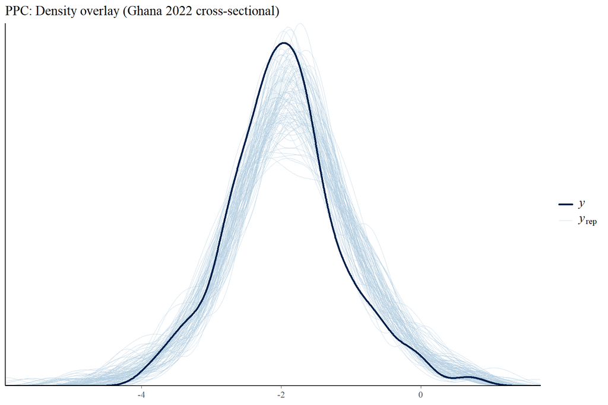

```r
y_obs_cs <- stan_data[["GHA_CS_2022"]]$y
y_rep_cs <- fit_gha_cs$draws("y_rep", format = "matrix")

ppc_dens_overlay(y = y_obs_cs, yrep = y_rep_cs[1:100, ]) +
  labs(title = "PPC: Density overlay (Ghana 2022 cross-sectional)")
```

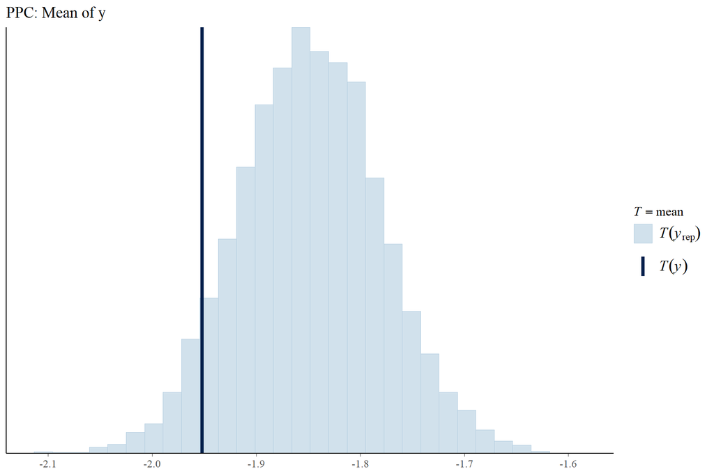

```r
ppc_stat(y = y_obs_cs, yrep = y_rep_cs, stat = "mean") +
  labs(title = "PPC: Mean of y")
```

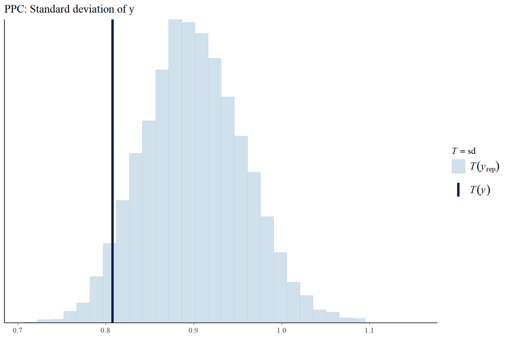

```r
ppc_stat(y = y_obs_cs, yrep = y_rep_cs, stat = "sd") +
  labs(title = "PPC: Standard deviation of y")
```

## 10.2 Space-Time Model: All Three Countries

We fit the space-time model separately for each country. Country-specific fitting (rather than a single pooled model) follows the established convention in DHS-based SAE work (Wakefield et al. 2020; Wu et al. 2021) and is justified by structural differences in graph topology, transmission dynamics, and survey design.

```r
mod_st <- cmdstan_model("fh_bym2_typeI.stan")

fit_st <- list()

for (iso in c("GHA", "BFA", "CIV")) {
  cat("\n========== Fitting space-time model for", iso, "==========\n")

  fit_st[[iso]] <- mod_st$sample(
    data            = stan_data[[paste0(iso, "_ST")]],
    chains          = 4,
    parallel_chains = 4,
    iter_warmup     = 1500,
    iter_sampling   = 2000,
    adapt_delta     = 0.99,
    max_treedepth   = 14,
    seed            = 1729,
    refresh         = 500
  )

  cat("\nDiagnostics for", iso, ":\n")
  print(fit_st[[iso]]$diagnostic_summary())
}
```

```
##
## ========== Fitting space-time model for GHA ==========
## Running MCMC with 4 parallel chains...
##
## Chain 1 Iteration:    1 / 3500 [  0%]  (Warmup)
## Chain 2 Iteration:    1 / 3500 [  0%]  (Warmup)
## Chain 3 Iteration:    1 / 3500 [  0%]  (Warmup)
## Chain 4 Iteration:    1 / 3500 [  0%]  (Warmup)
## Chain 4 Iteration:  500 / 3500 [ 14%]  (Warmup)
## Chain 2 Iteration:  500 / 3500 [ 14%]  (Warmup)
## Chain 1 Iteration:  500 / 3500 [ 14%]  (Warmup)
## Chain 3 Iteration:  500 / 3500 [ 14%]  (Warmup)
## Chain 4 Iteration: 1000 / 3500 [ 28%]  (Warmup)
## Chain 1 Iteration: 1000 / 3500 [ 28%]  (Warmup)
## Chain 2 Iteration: 1000 / 3500 [ 28%]  (Warmup)
## Chain 3 Iteration: 1000 / 3500 [ 28%]  (Warmup)
## Chain 4 Iteration: 1500 / 3500 [ 42%]  (Warmup)
## Chain 4 Iteration: 1501 / 3500 [ 42%]  (Sampling)
## Chain 1 Iteration: 1500 / 3500 [ 42%]  (Warmup)
## Chain 1 Iteration: 1501 / 3500 [ 42%]  (Sampling)
## Chain 2 Iteration: 1500 / 3500 [ 42%]  (Warmup)
## Chain 2 Iteration: 1501 / 3500 [ 42%]  (Sampling)
## Chain 3 Iteration: 1500 / 3500 [ 42%]  (Warmup)
## Chain 3 Iteration: 1501 / 3500 [ 42%]  (Sampling)
## Chain 4 Iteration: 2000 / 3500 [ 57%]  (Sampling)
## Chain 1 Iteration: 2000 / 3500 [ 57%]  (Sampling)
## Chain 2 Iteration: 2000 / 3500 [ 57%]  (Sampling)
## Chain 4 Iteration: 2500 / 3500 [ 71%]  (Sampling)
## Chain 3 Iteration: 2000 / 3500 [ 57%]  (Sampling)
## Chain 4 Iteration: 3000 / 3500 [ 85%]  (Sampling)
## Chain 2 Iteration: 2500 / 3500 [ 71%]  (Sampling)
## Chain 1 Iteration: 2500 / 3500 [ 71%]  (Sampling)
## Chain 4 Iteration: 3500 / 3500 [100%]  (Sampling)
## Chain 4 finished in 142.8 seconds.
## Chain 3 Iteration: 2500 / 3500 [ 71%]  (Sampling)
## Chain 2 Iteration: 3000 / 3500 [ 85%]  (Sampling)
## Chain 1 Iteration: 3000 / 3500 [ 85%]  (Sampling)
## Chain 3 Iteration: 3000 / 3500 [ 85%]  (Sampling)
## Chain 2 Iteration: 3500 / 3500 [100%]  (Sampling)
## Chain 2 finished in 187.7 seconds.
```

[output cut: 13 more lines]

```
##
## $num_max_treedepth
## [1] 0 0 0 0
##
## $ebfmi
## [1] 0.9071695 0.8370151 0.8465147 0.9081542
##
##
## ========== Fitting space-time model for BFA ==========
## Running MCMC with 4 parallel chains...
##
## Chain 1 Iteration:    1 / 3500 [  0%]  (Warmup)
## Chain 2 Iteration:    1 / 3500 [  0%]  (Warmup)
## Chain 3 Iteration:    1 / 3500 [  0%]  (Warmup)
## Chain 4 Iteration:    1 / 3500 [  0%]  (Warmup)
```

```
## Chain 4 Iteration:  500 / 3500 [ 14%]  (Warmup)
## Chain 3 Iteration:  500 / 3500 [ 14%]  (Warmup)
## Chain 2 Iteration:  500 / 3500 [ 14%]  (Warmup)
## Chain 1 Iteration:  500 / 3500 [ 14%]  (Warmup)
## Chain 4 Iteration: 1000 / 3500 [ 28%]  (Warmup)
## Chain 1 Iteration: 1000 / 3500 [ 28%]  (Warmup)
## Chain 2 Iteration: 1000 / 3500 [ 28%]  (Warmup)
## Chain 3 Iteration: 1000 / 3500 [ 28%]  (Warmup)
## Chain 1 Iteration: 1500 / 3500 [ 42%]  (Warmup)
## Chain 1 Iteration: 1501 / 3500 [ 42%]  (Sampling)
## Chain 4 Iteration: 1500 / 3500 [ 42%]  (Warmup)
## Chain 4 Iteration: 1501 / 3500 [ 42%]  (Sampling)
## Chain 2 Iteration: 1500 / 3500 [ 42%]  (Warmup)
## Chain 2 Iteration: 1501 / 3500 [ 42%]  (Sampling)
## Chain 3 Iteration: 1500 / 3500 [ 42%]  (Warmup)
## Chain 3 Iteration: 1501 / 3500 [ 42%]  (Sampling)
## Chain 1 Iteration: 2000 / 3500 [ 57%]  (Sampling)
## Chain 4 Iteration: 2000 / 3500 [ 57%]  (Sampling)
## Chain 2 Iteration: 2000 / 3500 [ 57%]  (Sampling)
## Chain 3 Iteration: 2000 / 3500 [ 57%]  (Sampling)
## Chain 1 Iteration: 2500 / 3500 [ 71%]  (Sampling)
## Chain 4 Iteration: 2500 / 3500 [ 71%]  (Sampling)
## Chain 2 Iteration: 2500 / 3500 [ 71%]  (Sampling)
## Chain 3 Iteration: 2500 / 3500 [ 71%]  (Sampling)
## Chain 1 Iteration: 3000 / 3500 [ 85%]  (Sampling)
## Chain 4 Iteration: 3000 / 3500 [ 85%]  (Sampling)
## Chain 2 Iteration: 3000 / 3500 [ 85%]  (Sampling)
## Chain 3 Iteration: 3000 / 3500 [ 85%]  (Sampling)
## Chain 1 Iteration: 3500 / 3500 [100%]  (Sampling)
## Chain 1 finished in 233.1 seconds.
## Chain 4 Iteration: 3500 / 3500 [100%]  (Sampling)
## Chain 4 finished in 234.6 seconds.
## Chain 2 Iteration: 3500 / 3500 [100%]  (Sampling)
## Chain 2 finished in 235.8 seconds.
## Chain 3 Iteration: 3500 / 3500 [100%]  (Sampling)
## Chain 3 finished in 239.9 seconds.
##
## All 4 chains finished successfully.
## Mean chain execution time: 235.8 seconds.
## Total execution time: 240.1 seconds.
##
##
## Diagnostics for BFA :
## $num_divergent
## [1] 0 0 0 0
##
## $num_max_treedepth
## [1] 0 0 0 0
##
## $ebfmi
## [1] 0.8920802 0.9109156 0.8558987 0.8773316
##
##
## ========== Fitting space-time model for CIV ==========
## Running MCMC with 4 parallel chains...
##
## Chain 1 Iteration:    1 / 3500 [  0%]  (Warmup)
## Chain 2 Iteration:    1 / 3500 [  0%]  (Warmup)
## Chain 3 Iteration:    1 / 3500 [  0%]  (Warmup)
## Chain 4 Iteration:    1 / 3500 [  0%]  (Warmup)
```

```
## Chain 1 Iteration:  500 / 3500 [ 14%]  (Warmup)
## Chain 4 Iteration:  500 / 3500 [ 14%]  (Warmup)
## Chain 2 Iteration:  500 / 3500 [ 14%]  (Warmup)
## Chain 3 Iteration:  500 / 3500 [ 14%]  (Warmup)
## Chain 1 Iteration: 1000 / 3500 [ 28%]  (Warmup)
## Chain 4 Iteration: 1000 / 3500 [ 28%]  (Warmup)
## Chain 2 Iteration: 1000 / 3500 [ 28%]  (Warmup)
## Chain 3 Iteration: 1000 / 3500 [ 28%]  (Warmup)
## Chain 1 Iteration: 1500 / 3500 [ 42%]  (Warmup)
## Chain 1 Iteration: 1501 / 3500 [ 42%]  (Sampling)
## Chain 4 Iteration: 1500 / 3500 [ 42%]  (Warmup)
## Chain 4 Iteration: 1501 / 3500 [ 42%]  (Sampling)
## Chain 3 Iteration: 1500 / 3500 [ 42%]  (Warmup)
## Chain 2 Iteration: 1500 / 3500 [ 42%]  (Warmup)
## Chain 3 Iteration: 1501 / 3500 [ 42%]  (Sampling)
## Chain 2 Iteration: 1501 / 3500 [ 42%]  (Sampling)
## Chain 1 Iteration: 2000 / 3500 [ 57%]  (Sampling)
## Chain 4 Iteration: 2000 / 3500 [ 57%]  (Sampling)
## Chain 3 Iteration: 2000 / 3500 [ 57%]  (Sampling)
## Chain 2 Iteration: 2000 / 3500 [ 57%]  (Sampling)
## Chain 1 Iteration: 2500 / 3500 [ 71%]  (Sampling)
## Chain 3 Iteration: 2500 / 3500 [ 71%]  (Sampling)
## Chain 4 Iteration: 2500 / 3500 [ 71%]  (Sampling)
## Chain 2 Iteration: 2500 / 3500 [ 71%]  (Sampling)
## Chain 1 Iteration: 3000 / 3500 [ 85%]  (Sampling)
## Chain 3 Iteration: 3000 / 3500 [ 85%]  (Sampling)
## Chain 4 Iteration: 3000 / 3500 [ 85%]  (Sampling)
## Chain 1 Iteration: 3500 / 3500 [100%]  (Sampling)
## Chain 1 finished in 74.5 seconds.
## Chain 2 Iteration: 3000 / 3500 [ 85%]  (Sampling)
## Chain 3 Iteration: 3500 / 3500 [100%]  (Sampling)
## Chain 3 finished in 75.0 seconds.
## Chain 4 Iteration: 3500 / 3500 [100%]  (Sampling)
## Chain 4 finished in 78.4 seconds.
## Chain 2 Iteration: 3500 / 3500 [100%]  (Sampling)
## Chain 2 finished in 86.5 seconds.
##
## All 4 chains finished successfully.
## Mean chain execution time: 78.6 seconds.
## Total execution time: 86.7 seconds.
##
##
## Diagnostics for CIV :
## $num_divergent
## [1] 0 0 0 0
##
## $num_max_treedepth
## [1] 0 0 0 0
##
## $ebfmi
## [1] 0.8417835 0.8843729 0.7428408 0.7995709
```

## 10.3 Summary Across Countries

```r
summary_all <- map_dfr(c("GHA", "BFA", "CIV"), function(iso) {
  draws <- fit_st[[iso]]$draws(
    variables = c("mu", "delta_2", "sigma_b", "phi", "sigma_gamma",
                  "p_round1", "p_round2"),
    format = "draws_matrix"
  )

  tibble(
    country  = iso,
    variable = colnames(draws),
    mean     = colMeans(draws),
    median   = apply(draws, 2, median),
    lower    = apply(draws, 2, quantile, 0.025),
    upper    = apply(draws, 2, quantile, 0.975),
    rhat     = apply(draws, 2, posterior::rhat),
    ess_bulk = apply(draws, 2, posterior::ess_bulk)
  )
})

print(summary_all)
```

```
## # A tibble: 21 × 8
##    country variable      mean median  lower  upper  rhat ess_bulk
##    <chr>   <chr>        <dbl>  <dbl>  <dbl>  <dbl> <dbl>    <dbl>
##  1 GHA     mu          -0.825 -0.825 -0.964 -0.691  1.00    3366.
##  2 GHA     delta_2     -1.14  -1.14  -1.33  -0.947  1.00    2097.
##  3 GHA     sigma_b      0.720  0.702  0.536  0.996  1.00    1653.
##  4 GHA     phi          0.471  0.473  0.154  0.766  1.00    1582.
##  5 GHA     sigma_gamma  0.521  0.519  0.440  0.613  1.00    2122.
##  6 GHA     p_round1     0.305  0.305  0.276  0.334  1.00    3366.
##  7 GHA     p_round2     0.123  0.123  0.106  0.141  1.00    3051.
##  8 BFA     mu           0.909  0.911  0.704  1.10   1.00     656.
##  9 BFA     delta_2     -2.52  -2.52  -2.87  -2.12   1.00     566.
## 10 BFA     sigma_b      1.04   1.02   0.748  1.43   1.00     590.
## # ℹ 11 more rows
```

# 11 Posterior Analysis and Visualisation

## 11.1 Prior vs Posterior Comparison (Ghana Space-Time)

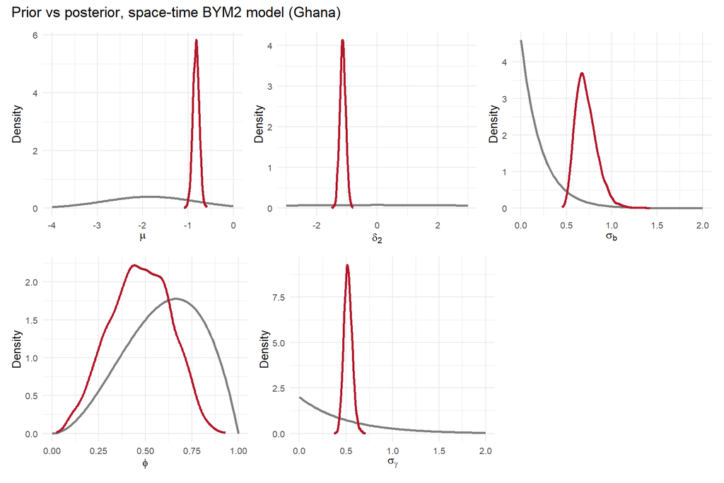

```r
post_draws <- fit_st[["GHA"]]$draws(
  c("mu", "delta_2", "sigma_b", "phi", "sigma_gamma"),
  format = "draws_df"
)

prior_post_plot <- function(post_var, prior_fun, x_range, label) {
  ggplot() +
    geom_function(fun = prior_fun, xlim = x_range,
                  aes(colour = "Prior"), linewidth = 0.9) +
    geom_density(data = post_draws,
                 aes(x = .data[[post_var]], colour = "Posterior"),
                 linewidth = 0.9) +
    scale_colour_manual(values = c(Prior = "grey50", Posterior = "#b2182b")) +
    labs(x = label, y = "Density", colour = NULL) +
    theme_minimal(base_size = 10) +
    theme(legend.position = "none")
}

p_mu     <- prior_post_plot("mu",          ~ dnorm(.x, -1.85, 1), c(-4, 0),  expression(mu))
p_delta  <- prior_post_plot("delta_2",     ~ dnorm(.x, 0, 5),     c(-3, 3),  expression(delta[2]))
p_sigb   <- prior_post_plot("sigma_b",     ~ dexp(.x, 4.6),       c(0, 2),   expression(sigma[b]))
p_phi    <- prior_post_plot("phi",         ~ dbeta(.x, 3, 2),     c(0, 1),   expression(phi))
p_siggam <- prior_post_plot("sigma_gamma", ~ dexp(.x, 2),         c(0, 2),   expression(sigma[gamma]))

(p_mu | p_delta | p_sigb) / (p_phi | p_siggam | plot_spacer()) +
  plot_annotation(title = "Prior vs posterior, space-time BYM2 model (Ghana)")
```

## 11.2 Covariate Effects Across Countries

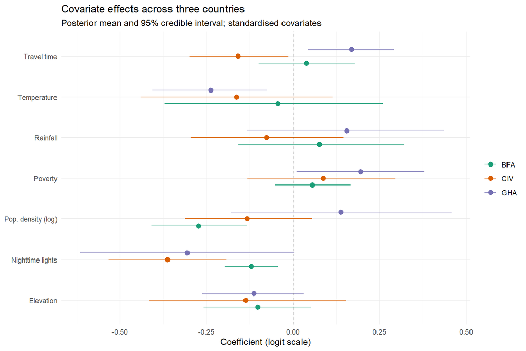

```r
covar_labels <- c("Elevation", "Rainfall", "Nighttime lights", "Temperature",
                  "Travel time", "Pop. density (log)", "Poverty")

extract_beta <- function(fit, iso) {
  fit$summary("beta",
              mean = mean, median = median,
              lower = ~ unname(quantile(.x, 0.025)),
              upper = ~ unname(quantile(.x, 0.975))) %>%
    mutate(country = iso,
           covariate = covar_labels[seq_len(n())])
}

beta_all <- map_dfr(c("GHA", "BFA", "CIV"),
                    function(iso) extract_beta(fit_st[[iso]], iso))

ggplot(beta_all, aes(x = mean, y = covariate, colour = country)) +
  geom_pointrange(aes(xmin = lower, xmax = upper),
                  position = position_dodge(width = 0.5)) +
  geom_vline(xintercept = 0, linetype = "dashed", colour = "grey40") +
  scale_colour_brewer(palette = "Dark2", name = NULL) +
  labs(x = "Coefficient (logit scale)", y = NULL,
       title = "Covariate effects across three countries",
       subtitle = "Posterior mean and 95% credible interval; standardised covariates") +
  theme_minimal(base_size = 11)
```

## 11.3 Prevalence Maps (All Countries, Both Rounds)

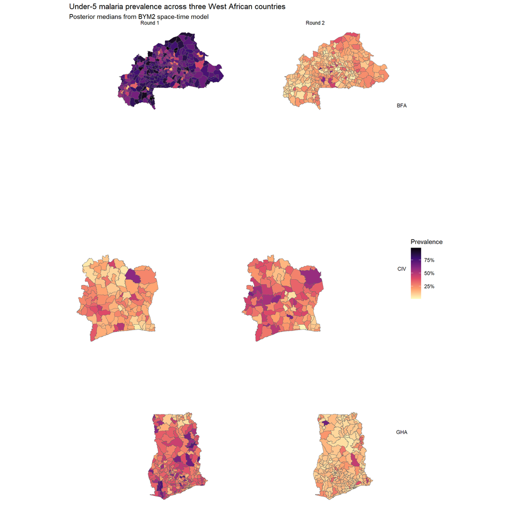

```r
make_prev_map_df <- function(iso, round) {
  prev_sum <- fit_st[[iso]]$summary("prevalence",
    median = ~ median(.x),
    lower  = ~ quantile(.x, 0.025),
    upper  = ~ quantile(.x, 0.975)
  ) %>%
    mutate(row_id = as.integer(gsub("prevalence\\[|\\]", "", variable))) %>%
    left_join(
      panels[[iso]] %>% mutate(row_id = row_number()) %>%
        select(row_id, district_id, round_id),
      by = "row_id"
    ) %>%
    filter(round_id == round) %>%
    left_join(district_lookups[[iso]] %>% select(district_id, district_code),
              by = "district_id")

  districts_raw[[iso]] %>%
    left_join(prev_sum, by = "district_code") %>%
    mutate(country = iso, round_label = paste("Round", round))
}

all_maps <- map_dfr(c("GHA", "BFA", "CIV"),
                    function(iso) bind_rows(
                      make_prev_map_df(iso, 1),
                      make_prev_map_df(iso, 2)
                    ))

ggplot(all_maps) +
  geom_sf(aes(fill = median), colour = "grey40", linewidth = 0.1) +
  scale_fill_viridis_c(name = "Prevalence",
                       labels = scales::percent_format(accuracy = 1),
                       option = "magma", direction = -1) +
  facet_grid(country ~ round_label) +
  labs(title = "Under-5 malaria prevalence across three West African countries",
       subtitle = "Posterior medians from BYM2 space-time model") +
  theme_void(base_size = 11) +
  theme(legend.position = "right")
```

## 11.4 District Trend Deviations (Ghana)

The interaction term captures district-specific deviations from the national trend, recoverable via $\gamma_i^*$. Negative values indicate districts that declined faster than the national average; positive values indicate stagnant or rising trajectories. Districts with bold outlines have 95% credible intervals that exclude zero.

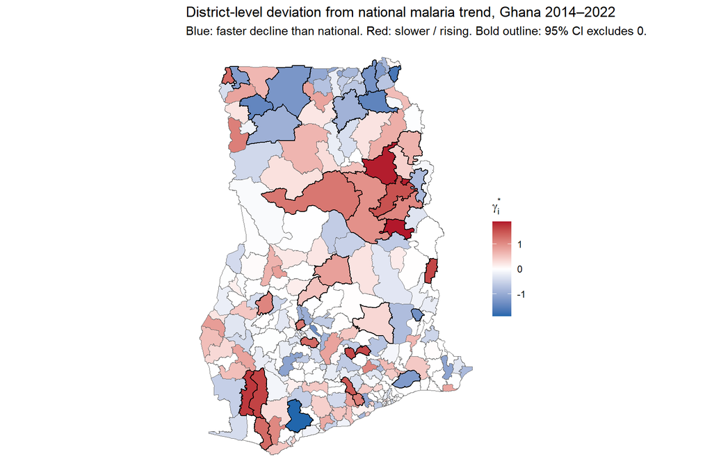

```r
dev_summary_gha <- fit_st[["GHA"]]$summary("gamma_star",
  median = ~ median(.x),
  lower  = ~ unname(quantile(.x, 0.025)),
  upper  = ~ unname(quantile(.x, 0.975))
) %>%
  mutate(
    district_id = as.integer(gsub("gamma_star\\[|\\]", "", variable)),
    confident = (lower > 0) | (upper < 0)
  ) %>%
  left_join(district_lookups[["GHA"]] %>%
              select(district_id, district_code, district_name),
            by = "district_id")

map_dev <- districts_raw[["GHA"]] %>%
  left_join(dev_summary_gha, by = "district_code")

dev_limit <- max(abs(range(map_dev$median, na.rm = TRUE)))

ggplot(map_dev) +
  geom_sf(aes(fill = median), colour = "grey40", linewidth = 0.1) +
  scale_fill_gradient2(
    name = expression(gamma[i]^"*"),
    low = "#2166ac", mid = "white", high = "#b2182b",
    midpoint = 0, limits = c(-dev_limit, dev_limit)
  ) +
  geom_sf(data = map_dev %>% filter(confident),
          fill = NA, colour = "black", linewidth = 0.4) +
  labs(
    title = "District-level deviation from national malaria trend, Ghana 2014–2022",
    subtitle = "Blue: faster decline than national. Red: slower / rising. Bold outline: 95% CI excludes 0."
  ) +
  theme_void(base_size = 11)
```

## 11.5 Top Trend-Deviating Districts

[figure not shown]

```r
top_neg <- dev_summary_gha %>% arrange(median) %>% head(10) %>%
  mutate(direction = "Faster decline")
top_pos <- dev_summary_gha %>% arrange(desc(median)) %>% head(10) %>%
  mutate(direction = "Slower / rising")

bind_rows(top_neg, top_pos) %>%
  mutate(district_name = fct_reorder(district_name, median)) %>%
  ggplot(aes(x = median, y = district_name, colour = direction)) +
  geom_pointrange(aes(xmin = lower, xmax = upper)) +
  geom_vline(xintercept = 0, linetype = "dashed") +
  scale_colour_manual(values = c("Faster decline" = "#2166ac",
                                 "Slower / rising" = "#b2182b")) +
  labs(x = expression(gamma[i]^"*" * " (logit scale)"), y = NULL,
       title = "Top districts with credible deviation from national trend, Ghana",
       colour = NULL) +
  theme_minimal(base_size = 11) +
  theme(legend.position = "bottom")
```

## 11.6 Uncertainty Maps

Districts with no direct estimates rely entirely on spatial borrowing, their credible intervals are wider, visible as higher values on the uncertainty map.

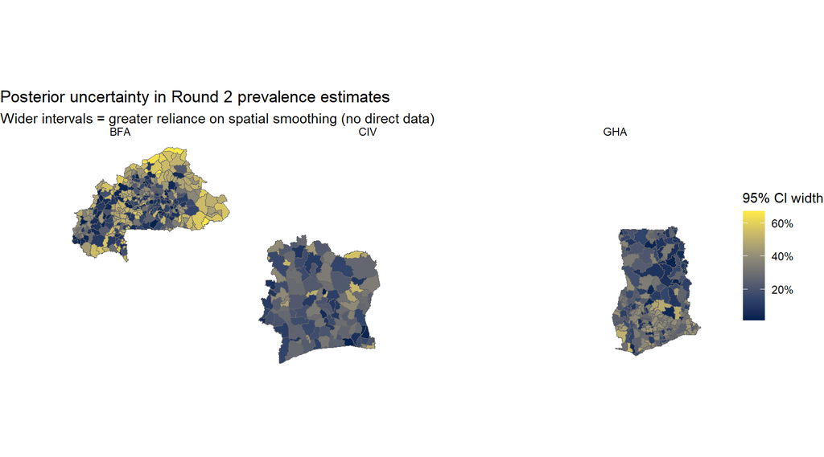

```r
make_uncertainty_df <- function(iso, round) {
  unc <- fit_st[[iso]]$summary("prevalence",
    width = ~ unname(quantile(.x, 0.975) - quantile(.x, 0.025))
  ) %>%
    mutate(row_id = as.integer(gsub("prevalence\\[|\\]", "", variable))) %>%
    left_join(
      panels[[iso]] %>% mutate(row_id = row_number()) %>%
        select(row_id, district_id, round_id, observed),
      by = "row_id"
    ) %>%
    filter(round_id == round) %>%
    left_join(district_lookups[[iso]] %>% select(district_id, district_code),
              by = "district_id")

  districts_raw[[iso]] %>%
    left_join(unc, by = "district_code") %>%
    mutate(country = iso)
}

unc_r2 <- map_dfr(c("GHA", "BFA", "CIV"),
                  function(iso) make_uncertainty_df(iso, 2))

ggplot(unc_r2) +
  geom_sf(aes(fill = width), colour = "grey40", linewidth = 0.1) +
  scale_fill_viridis_c(name = "95% CI width",
                       labels = scales::percent_format(accuracy = 1),
                       option = "cividis") +
  facet_wrap(~country) +
  labs(title = "Posterior uncertainty in Round 2 prevalence estimates",
       subtitle = "Wider intervals = greater reliance on spatial smoothing (no direct data)") +
  theme_void(base_size = 11)
```

# 12 Model Diagnostics

## 12.1 Cross-Sectional Trace Plots

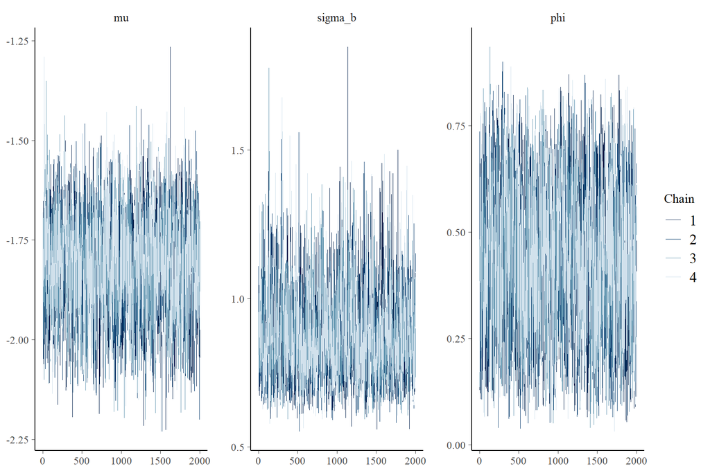

```r
mcmc_trace(fit_gha_cs$draws(c("mu", "sigma_b", "phi")))
```

## 12.2 Space-Time Diagnostics (Ghana)

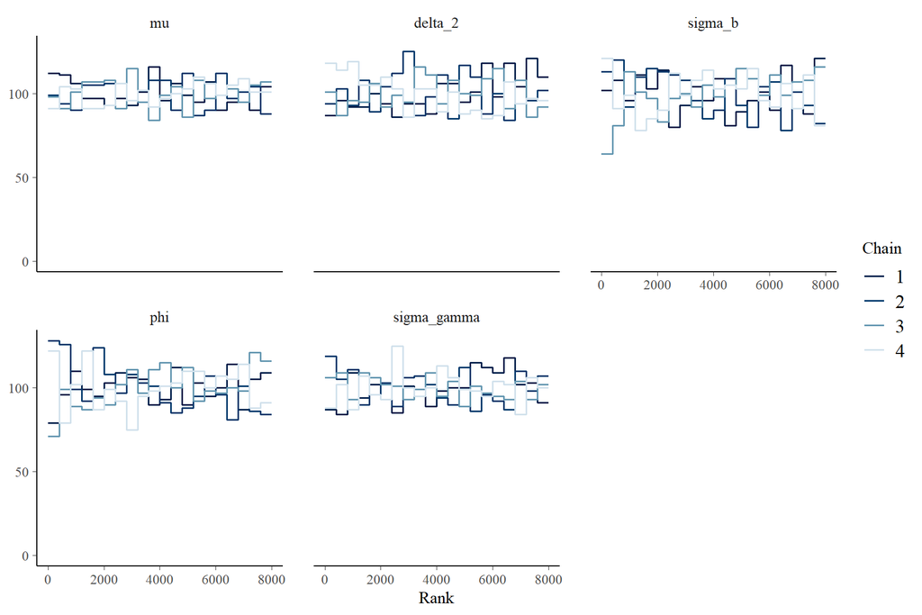

```r
mcmc_rank_overlay(fit_st[["GHA"]]$draws(
  c("mu", "delta_2", "sigma_b", "phi", "sigma_gamma")
))
```

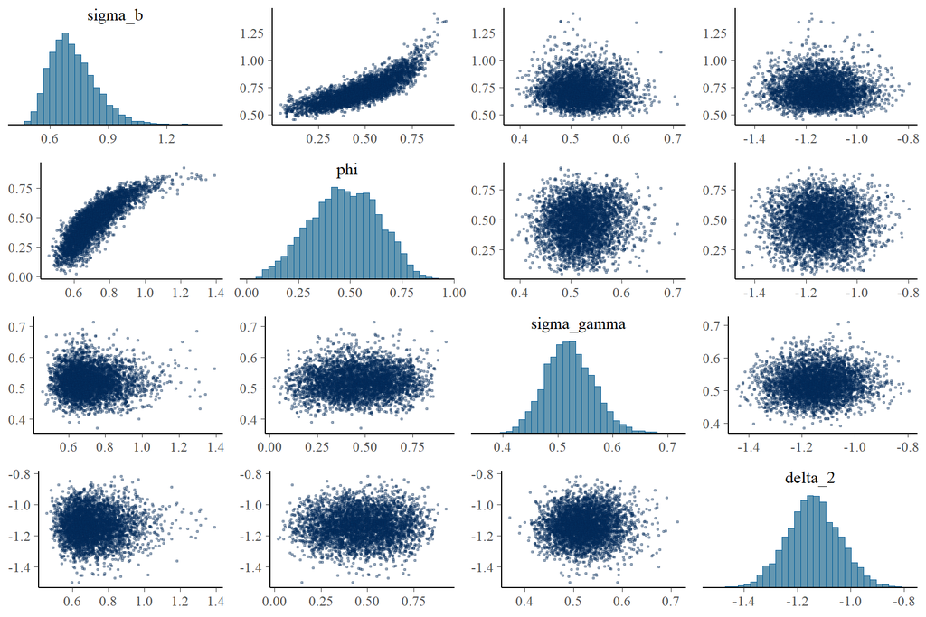

```r
mcmc_pairs(
  fit_st[["GHA"]]$draws(c("sigma_b", "phi", "sigma_gamma", "delta_2")),
  off_diag_args = list(size = 0.5, alpha = 0.3)
)
```